# Adding Zeros CPUE

Erin Johnston

10/25/2020

This is code for cleaning CCFRP data and adding zeros for CPUE analysis and visualization. Each fish species analyzed is not caught on every single drift, therefore it is necessary to add zeros for the drifts in which we don’t catch that species.

```r
library(tidyverse)
library(here) ## to read in data
library(plotrix) ## for standard error
library(patchwork) ## arrange multiple plots
```

# Cal Poly

This is code originally for just Cal Poly. See end of Rmd for similar code to clean and add zeros to Cal Poly and Moss Landing data

```r
CP_07_19 <- read_csv(here("Data", "CP20072019.csv"))

CP_07_19 %>%
  head ()
```

```
## # A tibble: 6 x 10
##   institution trip    drift   area  Site  species length gear   year anglerhours
##   <chr>       <chr>   <chr>   <chr> <chr> <chr>    <dbl> <chr> <dbl>       <dbl>
## 1 Cal Poly    BLT01_~ BLM071~ BL    MPA   BLU         20 BAR    2008        2.26
## 2 Cal Poly    BLT01_~ BLM071~ BL    MPA   BLU         19 FLY    2008        2.26
## 3 Cal Poly    BLT01_~ BLM071~ BL    MPA   GPR         20 FLY    2008        2.26
## 4 Cal Poly    BLT01_~ BLM071~ BL    MPA   BLU         19 BAR    2008        2.26
## 5 Cal Poly    BLT01_~ BLM071~ BL    MPA   GPR         20 FLY    2008        2.26
## 6 Cal Poly    BLT01_~ BLM071~ BL    MPA   GPR         26 BAR    2008        2.26
```

These data are from Cal Poly from 2007 to 2019. In this dataset, I queries access for the name of the school that collected the data, the trip identification number, the trip identification, area, protection status, species, length, gear type, year, and amount of time spent fishing.

## NA’s in the data

```r
CP_07_19 <- CP_07_19 %>%
  select(-gear)

CP_07_19 %>%
  select(everything())%>%
  summarise_all(funs(sum(is.na(.))))
```

```
## # A tibble: 1 x 9
##   institution  trip drift  area  Site species length  year anglerhours
##         <int> <int> <int> <int> <int>   <int>  <int> <int>       <int>
## 1           0     0     0     0     0       0     74     0          55
```

Yes, there are 74 fishes that do not have a length, there are 55 fishes that the angler hours were not recorded - it turns out that this all comes from one drift.

## Adding Zeros

This code will count the number of each species caught by drift, add NA’s to drifts in which there are none of that species caught, then add 0’s where the NA’s appear

```r
CP_count_zeros <- CP_07_19 %>%

  ## NAs:for 74 fish we didn't take length, for one drift there were no angler hours
  drop_na() %>%

  ## number of fish caught per drift by species
  count(drift, species)%>%

  ## from dply, renames the column 'n' into 'numbercaught
  rename(numbercaught = n)%>%

  ## this adds in NAs for the drifts where no fish were caught for a given species
  pivot_wider(names_from = drift,
              values_from = numbercaught) %>%

  ## back into long form
  pivot_longer(-species,
               names_to = "drift",
               values_to = "numbercaught") %>%

  #replacing NA with 0 where no fish were caught
  mutate(numbercaught=case_when(
    is.na(numbercaught)~0,
    TRUE~ as.numeric(numbercaught)
  ))
```

## Forming Dataset

This code will join drift metadata to the long-form dataset that includes zeros

```r
drift_metadata <- CP_07_19 %>%
  ## from dplyr: selecting the metadata, changing site to lowercase
  select(area, site=Site, year, anglerhours, drift) %>%
  ## gives us the metadata for each unique drift
  distinct()


## join the metadata and the zero's data
numcaught_withdrift <- left_join(CP_count_zeros, drift_metadata, by = "drift")
```

## Catch Per Unit Effort (CPUE)

To get CPUE, divide number of fishes of each species caught on drift by number of angler hours on that drift

```r
cpue_cp_zeros <- numcaught_withdrift %>%
  mutate(cpue = numbercaught/anglerhours)

## write out the csv
#write_csv(cpue_cp_zeros, here("Data/output", "2020-10-25_CPUE_calpoly.csv"))
```

# Cal Poly, SLO and Moss Landing Marine Laboratories

## Oct 2020: Will now be working with both CP and MLML data

```r
CP_MLML_to_2019 <- read_csv(here("Data", "CP_MLML_to_2019.csv"))

CP_MLML_to_2019 %>%
  select(everything())%>%
  summarise_all(funs(sum(is.na(.))))
```

```
## # A tibble: 1 x 12
##   group  trip  area  site month   day  year drift gridcell species length
##   <int> <int> <int> <int> <int> <int> <int> <int>    <int>   <int>  <int>
## 1     0     0     0     0     0     0     0     0        0       0    160
## # ... with 1 more variable: anglerhours <int>
```

```r
## 74 fishes from Cal Poly and 86 fishes from MLML missing length. There is one drift (PBM0911180603) that is missing information about angler hours.
## 74 CP fishes checked out in the paper datasheets - missing lengths
## 86 ML fishes unverified
## angler hours are missing from the database for drift PBM0911180603.
##BEN: fish with missing lengths were caught. CPUE is just numbers, so include. Just drop the drift (1 fewer replicate).

CP_MLML_to_2019 <- CP_MLML_to_2019 %>%
  ## dropped the 55 instances in which we didn't have angler hours
  drop_na(anglerhours)
```

```r
## each spp + drift combo and number caught (including 0)
CP_ML_count_zeros <- CP_MLML_to_2019 %>%
  count(drift, species)%>%
  rename(numbercaught = n)%>%
  pivot_wider(names_from = drift,
              values_from = numbercaught)%>%
  pivot_longer(-species,
               names_to = "drift",
               values_to = "numbercaught") %>%
   mutate(numbercaught=case_when(
    is.na(numbercaught)~0,
    TRUE~ as.numeric(numbercaught)
  ))

## metadata to add back together
## drift number is what will make this distinct
metadata_CP_ML <- CP_MLML_to_2019 %>%
  select(group, trip, area, site, month, day, year, gridcell, anglerhours, drift, drift)%>%
  distinct()

cpue_cp_ml <- left_join(CP_ML_count_zeros, metadata_CP_ML, by = "drift") %>%
  mutate(drift_cpue = numbercaught/anglerhours)
```

MPA/REF code cleaning. There are instances in which `site` was recorded as ‘MPA/REF’ instead of one or the other. We can tell which site was sampled by splicing out the third letter of the drift ID which will either be ‘M’ or ‘R’

```r
cpue_cp_ml_cleaned <- cpue_cp_ml %>%
  ##change `site` to `site_1`
  rename(site_1 = site)%>%
  ## take the 'M' or 'R' out of the drift name, which will make it clear if the MPA or REF was sampled
  transform(site_2 = substr(drift, 3, 3))%>%
  ## make new column called 'site'
  mutate(
    site = case_when(
      site_2 == "M" ~ "MPA",
      site_2 == "R" ~ "REF"
    )
  )%>%
  ## delete the other two site variations
  select(-site_1, - site_2)

#write_csv(cpue_cp_ml_cleaned, here("Data/output", "2020-10-25_CPUE_calpoly-mosslanding.csv"))
```

The reason I need to do this next step of several summarizations of cpue is to accoutn for potentially uneven sampling design. Cells are randomly selected with replacement throughout the season, which means that in a given year it is possible that CCFRP samples the same cell multiple times. Summarizing CPUE straight from the drift level to the year level does not account for this uneven sampling.

The `cpue_by_cell` and `cpue_by_site` dataframes below will guarantee that any uneven sampling is accounted for. Without it cpue may be artifically high for years in which one cell got sampled multiple times.

#### CPUE summarized at the cell level

The data in df `cpue_cp_ml_cleaned` are already summarized at the drift level. This df has two new columns: `cell_cpue` and `cell_se`, which are the mean cpue and standard error that occurs within each unique cell in each year for each species (regardless of drift in that year).

```r
cpue_by_cell <- cpue_cp_ml_cleaned %>%
  group_by(species, gridcell, site, area, year) %>%
  summarise(cell_cpue = mean(drift_cpue),
            cell_se = std.error(drift_cpue))

cpue_by_cell %>% filter(species == "BLU") %>% head(2)
```

```
## # A tibble: 2 x 7
## # Groups:   species, gridcell, site, area [1]
##   species gridcell site  area   year cell_cpue cell_se
##   <chr>   <chr>    <chr> <chr> <dbl>     <dbl>   <dbl>
## 1 BLU     AN01     REF   AN     2007     2.87    0.999
## 2 BLU     AN01     REF   AN     2008     0.148   0.148
```

#### CPUE summarized at the site level

The new df `cpue_by_site` has two new columns which are the standard error and mean of the cpue that occurs within each site (MPA or REF) in each area, in each year for each species in the dataset (regardless of cell + drift in that year).

```r
cpue_by_site <- cpue_by_cell %>%
  group_by(species, site, area, year) %>%
  summarise(site_cpue = mean(cell_cpue),
            site_se = std.error(cell_cpue))

cpue_by_site %>% filter(species == "BLU") %>% head(2)
```

```
## # A tibble: 2 x 6
## # Groups:   species, site, area [1]
##   species site  area   year site_cpue site_se
##   <chr>   <chr> <chr> <dbl>     <dbl>   <dbl>
## 1 BLU     MPA   AN     2007      1.34   0.357
## 2 BLU     MPA   AN     2008      2.49   0.573
```

#### CPUE summarized at the area level

The new df `cpue_by_area` has two new columns which are the standard error and mean of the cpue that occurs within each area in each year for each species in the dataset (regardless of site + cell + drift in that year).

```r
cpue_by_area <- cpue_by_site %>%
  group_by(species, area, year) %>%
  summarise(area_cpue = mean(site_cpue),
            area_se = std.error(site_cpue))

cpue_by_area %>% filter(species == "BLU") %>% head(2)
```

```
## # A tibble: 2 x 5
## # Groups:   species, area [1]
##   species area   year area_cpue area_se
##   <chr>   <chr> <dbl>     <dbl>   <dbl>
## 1 BLU     AN     2007      1.93   0.596
## 2 BLU     AN     2008      2.02   0.470
```

#### CPUE summarized at the year level

The new df `cpue_by_year` has two new columns which are the standard error and mean of the cpue that occurs within each year for each species (regardless of area + site + cell + drift in that year).

```r
cpue_by_year <- cpue_by_area %>%
  group_by(species, year) %>%
  summarise(year_cpue = mean(area_cpue),
            year_se = std.error(area_cpue))

cpue_by_year %>% filter(species == "BLU") %>% head(2)
```

```
## # A tibble: 2 x 4
## # Groups:   species [1]
##   species  year year_cpue year_se
##   <chr>   <dbl>     <dbl>   <dbl>
## 1 BLU      2007      4.06   2.31
## 2 BLU      2008      2.71   0.868
```

I took this same summarization all the way to the year level, but I think I am going to use the dataframe `cpue_by_site` for visualization because it retained area and site, so that I can break up graphs by those levels. I don’t expect the graphs will look too dissimilar to what I had before. I will graph the same plots with the original way of summarizing one cpue value per year from the drift data and then by summarizing to the cell level first.

## Example visualization

### The Original Graph

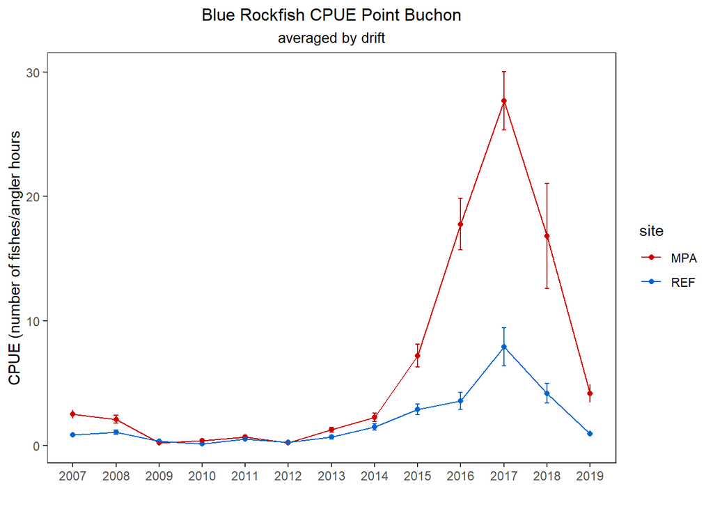

```r
orig_example <- cpue_cp_ml_cleaned %>%
  filter(species == "BLU", area == "PB")%>%
  group_by(year, site)%>%
  summarise(mean = mean(drift_cpue),
                    sd = sd (drift_cpue),
                    n = n(),
                    se = std.error (drift_cpue))%>%
  ggplot(aes(x = year, y = mean, color = site, group = site))+
  geom_point()+
  geom_line()+
  geom_errorbar(aes(ymin = mean - se, ymax = mean + se), width = 0.2,
                position = position_dodge(0))+
  scale_color_manual(values = c("#CC0000", "#0066CC"))+
  labs(y = "CPUE (number of fishes/angler hours", x = "",
       title = "Blue Rockfish CPUE Point Buchon",
       subtitle = "averaged by drift" )+
  scale_x_continuous(limits=c(2007,2019),breaks=seq(2007,2019,1))+
  theme_bw()+
  theme(panel.grid=element_blank(),
        plot.title = element_text(hjust = 0.5, size = 12),
        plot.subtitle = element_text(hjust = 0.5, size = 10))

plot(orig_example)
```

```r
#ggsave("orig.png", plot = orig_example, path = "C:/Users/erinj/Documents/Thesis/Figures", dpi = 1000, width = 6, height = 4)
#ggsave("new.png", plot = cell_sum_example,  path = "C:/Users/erinj/Documents/Thesis/Figures", dpi = 1000, width = 6, height = 4)
```

### The Cell Summarized Graph

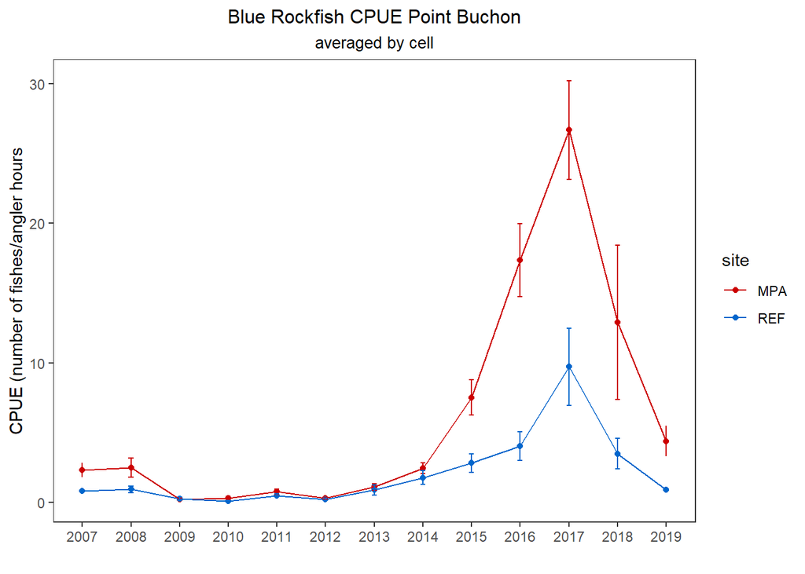

```r
cell_sum_example <- cpue_by_site %>%
  filter(species == "BLU", area == "PB")%>%
  ggplot(aes(x = year, y = site_cpue, color = site, group = site))+
  geom_point()+
  geom_line()+
  geom_errorbar(aes(ymin = site_cpue - site_se, ymax = site_cpue + site_se), width = 0.2,
                position = position_dodge(0))+
  scale_color_manual(values = c("#CC0000", "#0066CC"))+
  labs(y = "CPUE (number of fishes/angler hours", x = "",
       title = "Blue Rockfish CPUE Point Buchon",
       subtitle = "averaged by cell" )+
  scale_x_continuous(limits=c(2007,2019),breaks=seq(2007,2019,1))+
  theme_bw()+
  theme(panel.grid=element_blank(),
        plot.title = element_text(hjust = 0.5, size = 12),
        plot.subtitle = element_text(hjust = 0.5, size = 10))

plot(cell_sum_example)
```

I was right and wrong. The general trends are unaffected, but the graphs do look different. At first glance, it looks like the original yearly mean for the MPA was an overestimate of CPUE and the original yearly mean for REF was an underestimate of CPUE.